# Deterministic simulation of male-limited segregation distorter

## Load packages

```r
library(tidyverse) # for purrr, ggplot, dplyr and more
library(patchwork) # for combining plots
library(rcartocolor) # for cool colours
library(kableExtra) # scrolling tables
library(pander) # other nice tables
library(stickylabeller) # for labelling ggplot facets
library(geomtextpath)
library(ggnewscale) # for multiple scales in a single plot
```

## Introduction to the problem

Here, we use recursions to investigate the invasion of an autosomal segregation distorting (SD) allele (hereafter *SD*). We denote the resident allele, which does not cause segregation distortion, *W*. We explore models where segregation distortion occurs during 1) gametogenesis and 2) is limited to sperm development, such that a proportion $k$ of the gametes produced by a heterozygote carry the *SD* allele. In both cases, the distorting effect is limited to heterozygous individuals. As commonly observed in natural systems, we assume that homozygous *SDSD* genotypes are inviable, but that there are no viability costs associated with heterozygotes.

## Build the mating table

One of the more common elements of pop-gen models is the mating table. They illustrate the ‘rules of the game’.

Here, we use the “mating table” to list of all the possible mating types (e.g. a *WSD* mother with a *WSD* father, etc), the resulting possible offspring genotypes, and their associated frequencies. The precise values in the mating table are a function of *k* (i.e. the strength of segregation distortion). We assume that meiosis is Mendelian except in *WSD* individuals (or just males), and that all crosses produce a 50:50 sex ratio.

**Note**

Explore the code chunk below to see how we calculated zygote frequencies for every possible mating combination.

```r
make_mating_table <- function(k){

  make_offspring <- function(X, Y, type, zygote_freq){
    tibble(mother = X,
           father = Y,
           type,
           zygote_freq)
  }

  # Set up the 18 possible mating types - this just helps to build the combinations

  mating_types <- expand_grid(
    mother = c("WW_female",
               "WSD",
               "SDSD"),
    father = c("WW",
               "WSD",
               "SDSD"),
    sex_limited_drive = c("YES", "NO"))

  # Specify the possible offspring genotypes for all the potential crosses; we use these for the type argument in the make_offspring function

  # WW x WW

  g0 <- c("WW_female", "WW_male")

  # WSD x WW & WW x WSD

  g1 <- c("WW_female", "WW_male", "WSD_female", "WSD_male")

  # SDSD x WW & WW x SDSD

  g2 <- c("WSD_female", "WSD_male")

  # WSD x WSD

  g3 <- c("WW_female", "WW_male", "WSD_female", "WSD_male", "SDSD_female", "SDSD_male")

  # WSD x SDSD & SDSD x WSD

  g4 <- c("WSD_female", "WSD_male", "SDSD_female", "SDSD_male")

  # SDSD x SDSD

  g5 <- c("SDSD_female", "SDSD_male")


  # Now calculate the zygote frequencies for each cross

  # even frequency of four offspring types

  rep25 <- rep(0.25, 4)

  # even frequency between two offspring types

  rep5 <- rep(0.5, 2)

  # now offspring frequencies when there's drive

  # when there are 4 offspring genotypes

  p1 <- c(0.5 * (1 - k),
          0.5 * (1 - k),
          0.5 * k,
          0.5 * k)

  # when there are 6 offspring genotypes

  p2 <- c(0.25 * (1 - k),
          0.25 * (1 - k),
          (0.25 * (1 - k)) + (0.25 * k),
          (0.25 * (1 - k)) + (0.25 * k),
          0.25 * k,
          0.25 * k)

  # Now what happens when there is drive in both sexes

  # when there are 6 offspring genotypes

  p3 <- c(0.5 * ((1 - k)^2),
          0.5 * ((1 - k)^2),
          k*(1-k),
          k*(1-k),
          0.5*(k^2),
          0.5*(k^2))

  left_join(
    bind_rows(
      list(
        make_offspring("WW", "WW", g0, rep5),
        make_offspring("WW", "WSD", g1, p1),
        make_offspring("WW", "SDSD", g2, rep5),
        make_offspring("WSD", "WW", g1, rep25),
        make_offspring("WSD", "WSD", g3, p2),
        make_offspring("WSD", "SDSD", g4, rep25),
        make_offspring("SDSD", "WW", g2, rep5),
        make_offspring("SDSD", "WSD", g4, p1),
        make_offspring("SDSD", "SDSD", g5, rep5)
      )) %>%
      arrange(mother, father) %>%
      rename(zygote_freq_male_limited_drive = zygote_freq),


    bind_rows(
      list(
        make_offspring("WW", "WW", g0, rep5),
        make_offspring("WW", "WSD", g1, p1),
        make_offspring("WW", "SDSD", g2, rep5),
        make_offspring("WSD", "WW", g1, p1),
        make_offspring("WSD", "WSD", g3, p3),
        make_offspring("WSD", "SDSD", g4, p1),
        make_offspring("SDSD", "WW", g2, rep5),
        make_offspring("SDSD", "WSD", g4, p1),
        make_offspring("SDSD", "SDSD", g5, rep5)
      )) %>%
      arrange(mother, father) %>%
      rename(zygote_freq_heterozygote_drive = zygote_freq)
  )

}
```

## An example of a mating table

When $k$ = 0.9 we get

```r
# Make the table

make_mating_table(k = 0.9) %>%
  rename(`zygote type` = type,
         `zygote freq: male-limited drive` = zygote_freq_male_limited_drive,
         `zygote freq: drive in both sexes` = zygote_freq_heterozygote_drive) %>%
  kable() %>%
  kable_styling() %>%
  scroll_box(height = "500px")
```

| mother | father | zygote type | zygote freq: male-limited drive | zygote freq: drive in both sexes |
| --- | --- | --- | --- | --- |
| SDSD | SDSD | SDSD_female | 0.500 | 0.500 |
| SDSD | SDSD | SDSD_male | 0.500 | 0.500 |
| SDSD | WSD | WSD_female | 0.050 | 0.050 |
| SDSD | WSD | WSD_male | 0.050 | 0.050 |
| SDSD | WSD | SDSD_female | 0.450 | 0.450 |
| SDSD | WSD | SDSD_male | 0.450 | 0.450 |
| SDSD | WW | WSD_female | 0.500 | 0.500 |
| SDSD | WW | WSD_male | 0.500 | 0.500 |
| WSD | SDSD | WSD_female | 0.250 | 0.050 |
| WSD | SDSD | WSD_male | 0.250 | 0.050 |
| WSD | SDSD | SDSD_female | 0.250 | 0.450 |
| WSD | SDSD | SDSD_male | 0.250 | 0.450 |
| WSD | WSD | WW_female | 0.025 | 0.005 |
| WSD | WSD | WW_male | 0.025 | 0.005 |
| WSD | WSD | WSD_female | 0.250 | 0.090 |
| WSD | WSD | WSD_male | 0.250 | 0.090 |
| WSD | WSD | SDSD_female | 0.225 | 0.405 |
| WSD | WSD | SDSD_male | 0.225 | 0.405 |
| WSD | WW | WW_female | 0.250 | 0.050 |
| WSD | WW | WW_male | 0.250 | 0.050 |
| WSD | WW | WSD_female | 0.250 | 0.450 |
| WSD | WW | WSD_male | 0.250 | 0.450 |
| WW | SDSD | WSD_female | 0.500 | 0.500 |
| WW | SDSD | WSD_male | 0.500 | 0.500 |
| WW | WSD | WW_female | 0.050 | 0.050 |
| WW | WSD | WW_male | 0.050 | 0.050 |
| WW | WSD | WSD_female | 0.450 | 0.450 |
| WW | WSD | WSD_male | 0.450 | 0.450 |
| WW | WW | WW_female | 0.500 | 0.500 |
| WW | WW | WW_male | 0.500 | 0.500 |

## Determine the mating type frequencies of the population

```r
find_mating_type_frequencies <- function(pop){

  # Step 1

  pop$prop <- pop$prop * pop$egg_adult_viability # here's the selection step
  pop$prop <- pop$prop / sum(pop$prop) # now restandardise so that the props sum to 1

  # Step 2

  # Calculate the frequency of each single-mating combination

  mating_types <-
    expand_grid(mother = pop$type[str_detect(pop$type, "female")], # find all possible mother genotypes
                father = pop$type[!str_detect(pop$type, "female")]) %>% # find all possible father genotypes
    mutate(prop_matings = 0) # make placeholder column we will fill in below

  # find genotype frequencies calculated for each sex (mate choice means these will not necessarily be 50:50)

  female_frequencies <- pop %>% filter(str_detect(type, "female")) %>% mutate(prop = prop / sum(prop))
  male_frequencies <- pop %>% filter(!str_detect(type, "female")) %>% mutate(prop = prop / sum(prop))

  # This next step multiplies the proportion[i] of females with genotype[i] with the proportion[i] of males with genotype[i]

  for(i in 1:nrow(mating_types)){
    mating_types$prop_matings[i] <-
      female_frequencies$prop[female_frequencies$type == mating_types$mother[i]] *
      male_frequencies$prop[male_frequencies$type == mating_types$father[i]]
  }

  mating_types %>% # output
    rename(mating_type_freq = prop_matings) %>%
    select(mother, father, mating_type_freq) %>%
    # clean up the output by remving redundant info (makes it easier later)
    mutate(mother = str_remove_all(mother, "_female"),
           father = str_remove_all(father, "_male"))
}
```

## Create a simple function to find the population-wide frequency of *SD*

```r
calc_prop_SD <- function(pop){
  0.5 * sum(pop$prop[str_detect(pop$type, "WSD")]) + sum(pop$prop[str_detect(pop$type, "SDSD")])
}
```

## Build the main simulation function

This is how we actually run the recursions. This large function uses our two helper functions, `find_mating_type_frequencies` and `calc_prop_SD` that we build above.

**Note**

I wrote this code to be readable, not fast. The task is computationally quite manageable, making this an inexpensive trade-off. Functions like `left_join` should be avoided if you require faster code.

```r
run_recursions <- function(row, parameters, sex_limited){

  print(paste("Doing row", row)) # this tells you which row in the parameter space is being modelled

  # Get the focal parameter space out of parameters[row], this makes it easier later

  generations <- parameters$generations[row]
  k <- parameters$k[row]
  egg_adult_viability_WSD_female <- parameters$egg_adult_viability_WSD_female[row]
  egg_adult_viability_SDSD_female <- parameters$egg_adult_viability_SDSD_female[row]
  egg_adult_viability_WSD_male <- parameters$egg_adult_viability_WSD_male[row]
  egg_adult_viability_SDSD_male <- parameters$egg_adult_viability_SDSD_male[row]
  initial_freq_SD <- parameters$initial_freq_SD[row]

  # Make the initial population
  pop <-
    tibble(
      type = c("WW_female",
               "WSD_female",
               "SDSD_female",
               "WW_male",
               "WSD_male",
               "SDSD_male"),
      prop = c(0.5 * (1 - initial_freq_SD) ^ 2,
               0.5 * (1 - initial_freq_SD) * initial_freq_SD * 2,
               0.5 * (initial_freq_SD^2),
               0.5 * (1 - initial_freq_SD) ^ 2,
               0.5 * (1 - initial_freq_SD) * initial_freq_SD * 2,
               0.5 * (initial_freq_SD^2)),
      egg_adult_viability = c(1, egg_adult_viability_WSD_female,
                              egg_adult_viability_SDSD_female, 1,
                              egg_adult_viability_WSD_male, egg_adult_viability_SDSD_male)) %>%
    arrange(type)

  # Make the mating table for this specific parameter space

  mating_table <- make_mating_table(k) # we only have to load the pre-created table once

  # Input the fitnesses of each genotype

  fitnesses <- pop %>%
    select(type, egg_adult_viability)

  # Prepare for recursions
  current_generation <- 1
  keep_going <- TRUE # a quit condition, if this switches to false the sim will end

  # create a matrix to track the frequencies of SD every generation
  # specify two columns because we'd like to know the freq in zygotes and the freq in adults
  freq_table <- matrix(nrow = generations + 1, ncol = 2)
  # provide the first entry, starting with zygotes
  freq_table[1, ] <- initial_freq_SD

  # Iterate over generations

  while(current_generation <= generations & keep_going){

    # Use our pre-made function to enact viability selection, find the mating type frequencies and renormalise the frequencies to sum to one every generation

    mating_type_frequencies <- find_mating_type_frequencies(pop = pop)

    # Now make the new pop table, using the new mating type frequencies

    if(sex_limited == TRUE){ # drive is just through males
      pop <-
        left_join(mating_table, mating_type_frequencies, by = c("mother", "father")) %>%
        # find the offspring frequencies, this is where the distortion effect is coded
        mutate(prop = mating_type_freq * zygote_freq_male_limited_drive) %>%
        group_by(type) %>%
        summarise(prop = sum(prop)) %>%
        left_join(fitnesses, by = "type")
    } else{ # drive occurs in both sexes
      pop <-
        left_join(mating_table, mating_type_frequencies, by = c("mother", "father")) %>%
        # find the offspring frequencies, this is where the distortion effect is coded
        mutate(prop = mating_type_freq * zygote_freq_heterozygote_drive) %>%
        group_by(type) %>%
        summarise(prop = sum(prop)) %>%
        left_join(fitnesses, by = "type")
    }

    # update the results matrix
    # our pop matrix tracks the frequencies of zygotes, fill column one with these freqs
    freq_table[current_generation + 1, 1] <-
      pop %>% mutate(prop = prop/sum(prop)) %>%
      calc_prop_SD()

    # fill column two with allele frequencies among adults
    freq_table[current_generation + 1, 2] <-
      pop %>% mutate(prop = prop*egg_adult_viability) %>% mutate(prop = prop/sum(prop)) %>%
      calc_prop_SD()

    # Calculate the frequency of SD
    prop_SD <- calc_prop_SD(pop)
    # Quit early if SD fixes or goes extinct-ish
    if(prop_SD > 0.99 | prop_SD < 0.005) keep_going <- FALSE

    # Increment the generation counter by 1 and return to top of the 'while' loop
    current_generation <- current_generation + 1
  }

  freq_table # returns the final pop

}
```

# Build parameter space

```r
parameters <- rbind(
  expand_grid(
    generations = 1000,
    k = seq(from = 0.5, to = 1, by = 0.005),
    egg_adult_viability_WSD_female = 1,
    egg_adult_viability_SDSD_female = 0,
    egg_adult_viability_WSD_male = 1,
    egg_adult_viability_SDSD_male = 0,
    initial_freq_SD = 0.01)) %>%
  mutate(parameter_space_ID = row_number())
```

## Run the simulation

```r
if(!file.exists("simulation_results/sex_lim_results.rds")){
sex_lim_results <-
  lapply(1:nrow(parameters), run_recursions, parameters = parameters, sex_limited = TRUE)

saveRDS(sex_lim_results, "simulation_results/sex_lim_results.rds")

both_sexes_results <-
  lapply(1:nrow(parameters), run_recursions, parameters = parameters, sex_limited = FALSE)

saveRDS(both_sexes_results, "simulation_results/both_sexes_results.rds")
}else{
  sex_lim_results <- read_rds("simulation_results/sex_lim_results.rds")
  both_sexes_results <- read_rds("simulation_results/both_sexes_results.rds")
}
```

## Wrangle the results for plotting

Get the results from a single run

```r
single_run_sex_lim <-
  sex_lim_results[[81]] %>%
  as_tibble() %>%
  rename(Zygotes = V1,
         Adults = V2) %>%
  mutate(gen = 1:n(),
         drive = "Male-limited drive")

single_run_all_het <-
  both_sexes_results[[81]] %>%
  as_tibble() %>%
  rename(Zygotes = V1,
         Adults = V2) %>%
  mutate(gen = 1:n(),
         drive = "Drive in all heterozygotes")

single_run <-
  rbind(single_run_sex_lim,
        single_run_all_het) %>%
  pivot_longer(cols = 1:2, names_to = "Census point", values_to = "Frequency")
```

Get the endpoints of all simulations

```r
results_wrangler <-
  function(input, row){
    as.data.frame(input[row]) %>%
      filter(!is.na(X1)) %>%
      slice_tail(n = 1) %>%
      mutate(parameter_space_ID = row,
             X1 = round(X1, 3),
             X2 = round(X2, 3))
  }

sex_lim_tidy_results <-
  map_dfr(1:nrow(parameters),
          results_wrangler,
          input = sex_lim_results) %>%
  rename(Zygotes = X1,
         Adults = X2) %>%
  mutate(drive = "Male-limited drive") %>%
  left_join(parameters, by = "parameter_space_ID")

both_sexes_tidy_results <-
  map_dfr(1:nrow(parameters),
          results_wrangler,
          input = both_sexes_results) %>%
  rename(Zygotes = X1,
         Adults = X2) %>%
  mutate(drive = "Drive in all heterozygotes") %>%
  left_join(parameters, by = "parameter_space_ID")

complete_results <-
  bind_rows(sex_lim_tidy_results,
            both_sexes_tidy_results) %>%
  as_tibble() %>%
  pivot_longer(cols = Zygotes:Adults,
               names_to = "Census point",
                values_to = "Prop. driver")
```

## Plot the results

First, let’s plot the evolutionary trajectory of the *SD* allele when $k=0.9$.

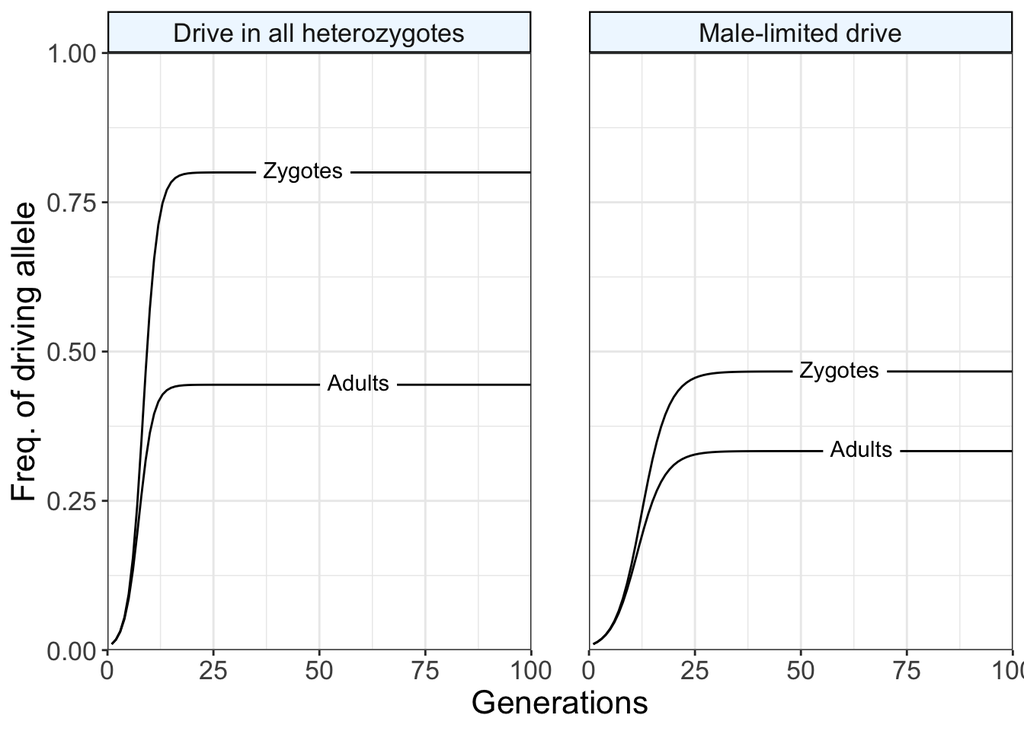

```r
single_run %>%
  ggplot(aes(x = gen, y = Frequency, group = `Census point`)) +
  geom_textline(aes(label = `Census point`), hjust = 0.75) +
  labs(x = "Generations",
       y = "Freq. of driving allele") +
  facet_wrap(~drive) +
  scale_x_continuous(expand = c(0, 0.01), limits = c(0,100)) +
  scale_y_continuous(expand = c(0, 0), limits = c(0, 1)) +
  theme_bw() +
  theme(text = element_text(size = 16),
        strip.background = element_rect(colour = "black",
                                        fill = "Aliceblue",
                                        size = .8),
        panel.spacing.x = unit(10, "mm"))
```

Now let’s plot the equilibrium frequency for all values of $k$

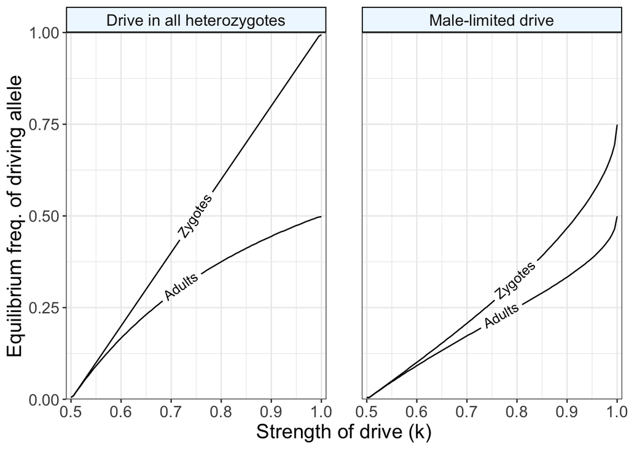

```r
complete_results %>%
  ggplot(aes(x = k, y = `Prop. driver`, group = `Census point`)) +
  geom_textline(aes(label = `Census point`)) +
  #geom_line(data = Bruck_results, colour = "orange") +
  labs(x = "Strength of drive (k)",
       y = "Equilibrium freq. of driving allele") +
  facet_wrap(~drive) +
  scale_x_continuous(expand = c(0, 0.01)) +
  scale_y_continuous(expand = c(0, 0), limits = c(0, 1)) +
  theme_bw() +
  theme(text = element_text(size = 16),
        strip.background = element_rect(colour = "black",
                                        fill = "Aliceblue",
                                        size = .8),
        panel.spacing.x = unit(10, "mm"))
```